# Site frequency spectrum of the whole population

J. Ignacio Lucas Lledó

2026-01-05

When using `ipyrad`’s data, `bpp` suggested in `2025-11-06` that the total ancestral variation was split between the two daughter populations: they did not seem to grow. But when using predicted genotypes from ANGSD in `2025-11-25`, the daughter populations seem more diverse than the ancestral ones. They actually seem to have grown over 5 (*C. farionis*) and 7-fold (*C. pseudofarionis*) with respect to the ancestral population. I suppose the reason is that the two populations accumulated low-frequency variants independently in recent times, which are even lower-frequency when considered a single population. Low frequency variants must have been missed by `ipyrad` under it’s conservative settings. To check this interpretation, I want to run ANGSD with all samples as a single population. I expect ANGSD to report an SFS more biased towards low frequency variants. Let’s see.

In `2025-06-12`, we removed a few thousand sites from analysis that appeared heterozygous in all samples from the same population:

| Dataset | Population | Total sites | Removed | Sites used |
| --- | --- | --- | --- | --- |
| Reference | C. farionis | 2101093 | 8344 | 2092749 |
| Reference | C. pseudofa. | 1875360 | 4470 | 1870890 |
| Rad loci | C. farionis | 3257248 | 7522 | 3249726 |
| Rad loci | C. pseudofa. | 3025512 | 4085 | 3021427 |

Now, pooling the two populations together, we must remove those sites all together, and use only sites valid in both populations. Using the `*.sites.txt` files in `2025-06-12/*/SFS/unfiltered/`, I manually count 1147152 and 1627689 sites common to both populations in the reference and rad loci data sets, respectively. Although the filters may affect the final number of sites included.

```bash
RADBAM=../2024-10-04/BAM
REFBAM=../2023-05-18/BAM
RADREF=../2024-10-04/radloci.fa
REFREF=../2023-05-15/assembly.fasta

if [ ! -d rad ]; then mkdir rad; fi
if [ ! -d ref ]; then mkdir ref; fi


if [ ! -e onesp.txt ]; then
   gawk '((NR > 1) && ($2 > 0.95)){
      print $1
   }' ../2024-10-05/summary.txt >  onesp.txt
   gawk '((NR > 1) && ($3 > 0.95)){
      print $1
   }' ../2024-10-05/summary.txt >> onesp.txt
fi

if [ ! -e rad/onesp.list ]; then
   find $RADBAM -name '*.bam' | grep -f onesp.txt | sort > rad/onesp.list
fi

if [ ! -e ref/onesp.list ]; then
   find $REFBAM -name '*.bam' | grep -f onesp.txt | sort > ref/onesp.list
fi

if [ ! -e rad/sites.txt.idx ]; then
   if [ ! -e rad/sites.txt ]; then
      sdiff ../2025-06-12/rad/SFS/unfiltered/farionis.sites.txt \
            ../2025-06-12/rad/SFS/unfiltered/pseudofarionis.sites.txt | \
      grep -v '[\|><]' | cut -f 1,2 > rad/sites.txt
   fi
   angsd sites index rad/sites.txt 1> rad/sites.log 2> rad/sites.err &
fi

if [ ! -e ref/sites.txt.idx ]; then
   if [ ! -e ref/sites.txt ]; then
      sdiff ../2025-06-12/ref/SFS/unfiltered/farionis.sites.txt \
            ../2025-06-12/ref/SFS/unfiltered/pseudofarionis.sites.txt | \
      grep -v '[\|><]' | cut -f 1,2 > ref/sites.txt
   fi
   angsd sites index ref/sites.txt 1> ref/sites.log 2> ref/sites.err &
fi
wait

for i in ref rad; do
   if [ ! -e $i/sites.chr.txt ]; then
      cut -f 1 $i/sites.txt | sort | uniq > $i/sites.chr.txt
   fi
   if [ ! -e $i/onesp.saf.idx ]; then
      REF=$RADREF
      if [ "$i" = "ref" ]; then
         REF=$REFREF
      fi
      angsd -b $i/onesp.list \
            -anc $REF \
            -ref $REF \
            -rf    $i/sites.chr.txt \
            -sites $i/sites.txt \
            -out   $i/onesp \
            -doGlf 1 \
            -GL 1 \
            -doSaf 1 \
            -doMajorMinor 1 \
            -minmapQ 30 \
            -minQ 30 \
            -only_proper_pairs 1 \
            -baq 1 \
            -minInd 60 \
            -setMinDepthInd 4 \
            -nThreads 8 1> $i/onesp.log \
            2> $i/onesp.err &
   fi
done
wait

for i in rad ref; do
   if [ ! -e $i/onesp.sfs ]; then
      realSFS -fold 1 $i/onesp.saf.idx \
      1> $i/onesp.sfs 2> $i/onesp.sfs.err &
   fi
done
wait
```

The logs report 1606945 and 1138572 sites analysed in the RAD-loci and reference data sets respectively.

## Nucleotide diversity

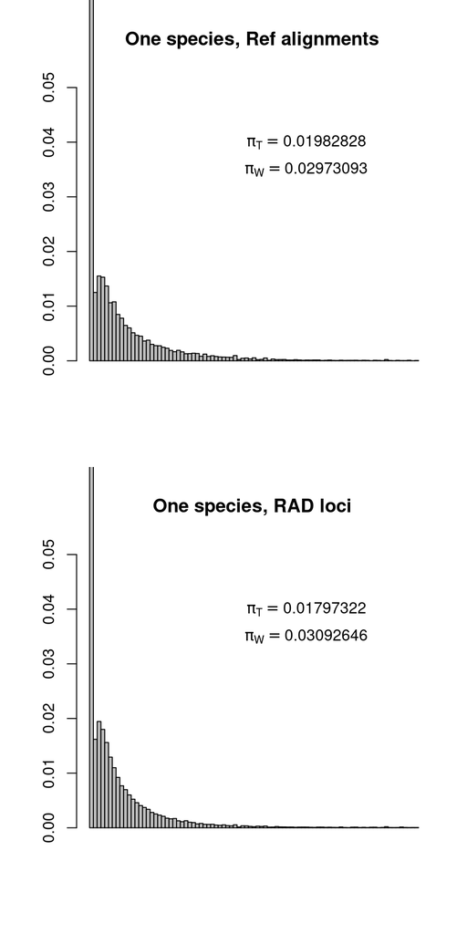

```r
PiTajima <- function(x, folded = TRUE){
   n <- length(x) - 1  # the SFS includes invariable sites and, if folded, 0 values for i > n/2
   a <- 1:(n/2)
   Theta <- (2/(n * (n-1))) * sum(x[2:(n/2 + 1)] * a * (n - a)) / sum(x)
   return(Theta)
}
PiWatterson <- function(x, folded = TRUE){
   n <- length(x) - 1
   a <- sum(1/(1:(n-1)))
   Theta <- sum(x[-1]) / (a * sum(x))
   return(Theta)
}

# SFS data and calculations
ref <- scan('ref/onesp.sfs', quiet = TRUE)
n <- (length(ref) - 1) / 2
ref.pi.T <- PiTajima(ref)
ref.pi.W <- PiWatterson(ref)

rad <- scan('rad/onesp.sfs', quiet = TRUE)
rad.pi.T <- PiTajima(rad)
rad.pi.W <- PiWatterson(rad)

# Plotting
par(mfrow = c(2, 1))
plot(c(0, n), c(0, 0.05), type = 'n', xlab = '', ylab = '', axes = FALSE,
     main = 'One species, Ref alignments')
barplot(ref[1:(n + 1)] / sum(ref), add = TRUE, space = 0)
text(2 * n / 3, 0.040,
     bquote(pi[T]==.(ref.pi.T)))
text(2 * n / 3, 0.035,
     bquote(pi[W]==.(ref.pi.W)))

plot(c(0, n), c(0, 0.05), type = 'n', xlab = '', ylab = '', axes = FALSE,
     main = 'One species, RAD loci')
barplot(rad[1:(n + 1)] / sum(rad), add = TRUE, space = 0)
text(2 * n / 3, 0.040,
     bquote(pi[T]==.(rad.pi.T)))
text(2 * n / 3, 0.035,
     bquote(pi[W]==.(rad.pi.W)))
```

For comparison with previous results, I type below the numbers. But they are not updated automatically, and some of them (`bpp`’s results) may be provisional at the time of writing. The sources are `2025-06-12` for ANGSD’s results of separate populations, the current document for ANGSD’s results of a single species (*Together*), and `2025-11-25` for `bpp`’s results.

| Source | Population | Estimator | Value |
| --- | --- | --- | --- |
| bpp | C. farionis | Post. mean | 0.015 |
| bpp | C. pseudofa. | Post. mean | 0.022 |
| bpp | Together | Post. mean | 0.014 |
| angsd | C. farionis | Tajima | 0.015 |
| angsd | C. pseudofa. | Tajima | 0.016 |
| angsd | Together | Tajima | 0.018 |
| angsd | C. farionis | Watterson | 0.020 |
| angsd | C. pseudofa. | Watterson | 0.019 |
| angsd | Together | Watterson | 0.031 |

The figures above are shown only for alignments to RAD loci, which is the only kind of data used by `bpp`. Keep in mind that loci used by `bpp` are a subset of the dataset aligned to RAD loci, with only 7 individuals used per locus. An arbitrary filter to avoid excess of heterozygosity may have biased `bpp`’s diversity estimates downwards.

The main conclusions from this comparsions are:

1. The nucleotide diversity of the two populations together, as a single species, is very similar to the diversities observed in individual populations, when measured by Tajima’s estimate or by the posterior’s mean. This is indicative of very little divergence.
2. Only Watterson’s estimate indicate a considerably higher diversity in the whole population, as compared to individual populations. This confirms the idea that the main contributions to differences between populations are due to low frequency variants, found in excess by all accounts.